# k-Means

Eudes Lapaz

2023-04-01

## Import Package

```r
library(FactoMineR)
library(factoextra)
library(CASdatasets)
library(tidyverse)
library(MASS)
```

```r
library(knitr)
library(ggplot2)
library(cowplot)
library(reshape2)
library(dplyr)
library(GGally)
library(corrplot)
library(carData)
library(car)
library(questionr)
library(multcomp)
library(dplyr)
library(leaps)
library(TeachingDemos)
library(FactoMineR)
library(factoextra)
library(ROCR)
library(plotROC)
```

# Etude CSP

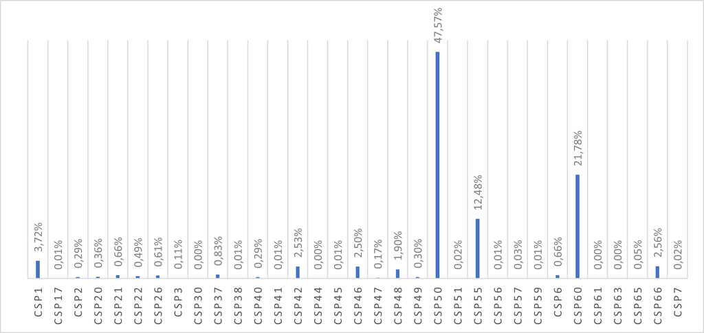

Une première analyse nous permet de rassembler toutes les CSP comportant moins de 1,5% des assurés dans une seule et même classe. Il s’agit des classes : CSP17,2,20,21,22,26,3,30,37,38,40,41,44,45,47,49,51,56,57,59,6,61,63,65 et 7.

La suite de notre étude ne portera donc que sur les classes :CSP1, 42, 46, 48, 50, 55, 60 et 66

```r
#J'ai procédé d'une autre manière. Voir encadré suivant
#On conserve que les CSP1, 42, 46, 48, 50, 55, 60 et 66

#data=subset(freMPL5,freMPL5$SocioCateg %in% c("CSP1","CSP42","CSP46","CSP48","CSP50","CSP55","CSP60","CSP66"))
```

### I) K-Means avec les variables ClaimInd et ClaimAmount

L’objectif est de constituer différents groupes d’individus à partir de leurs caractéristiques. Ces regroupement seront faits grâce à des similitudes partagées par des mêmes individus (à partir de calcul de distance : on se servira essentiellement de la distance euclidienne dans cette étude)

#### a) Clustering avec contrats regroupés par CSP

Dans la suite de cette section, on va regrouper, si possible, les 8 CSP restantes grâce à la méthode des k-means

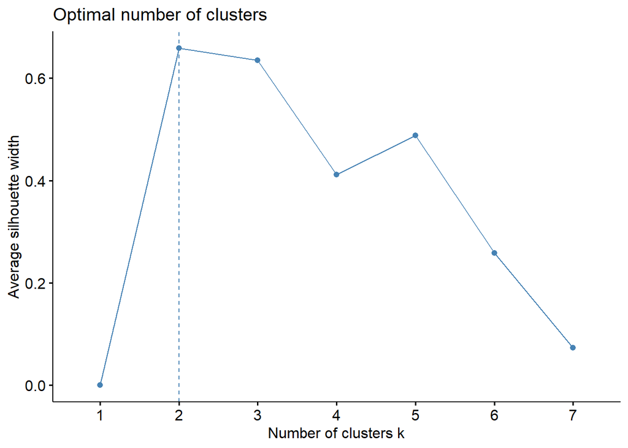

```r
#On centre chaque colonne de notre dataframe data afin de pouvoir procéder aux k-means
data_1=read.csv("data_CSP_1.csv",header=TRUE,sep=";",fill=F,row.names=1)
df=scale(data_1)
#Etude du nombre de clusterings que l'on va considérer grâce à différents critères

fviz_nbclust(data_1,  FUNcluster = kmeans ,c("silhouette", "wss", "gap_stat"),k.max=7)
```

```r
km.res <- kmeans(df, 2, nstart = 10)
km.res
```

```
## K-means clustering with 2 clusters of sizes 3, 5
##
## Cluster means:
##   Proportion.de.sinistres Montant.sinistre.moyen Exposure.moyenne.par.CSP
## 1              -1.0873082            -0.04084745               -1.1027156
## 2               0.6523849             0.02450847                0.6616293
##
## Clustering vector:
##  CSP1 CSP42 CSP46 CSP48 CSP50 CSP55 CSP60 CSP66
##     2     2     2     2     1     1     1     2
##
## Within cluster sum of squares by cluster:
## [1] 0.9457319 8.5348001
##  (between_SS / total_SS =  54.9 %)
##
## Available components:
##
## [1] "cluster"      "centers"      "totss"        "withinss"     "tot.withinss"
## [6] "betweenss"    "size"         "iter"         "ifault"
```

```
## Too few points to calculate an ellipse
```

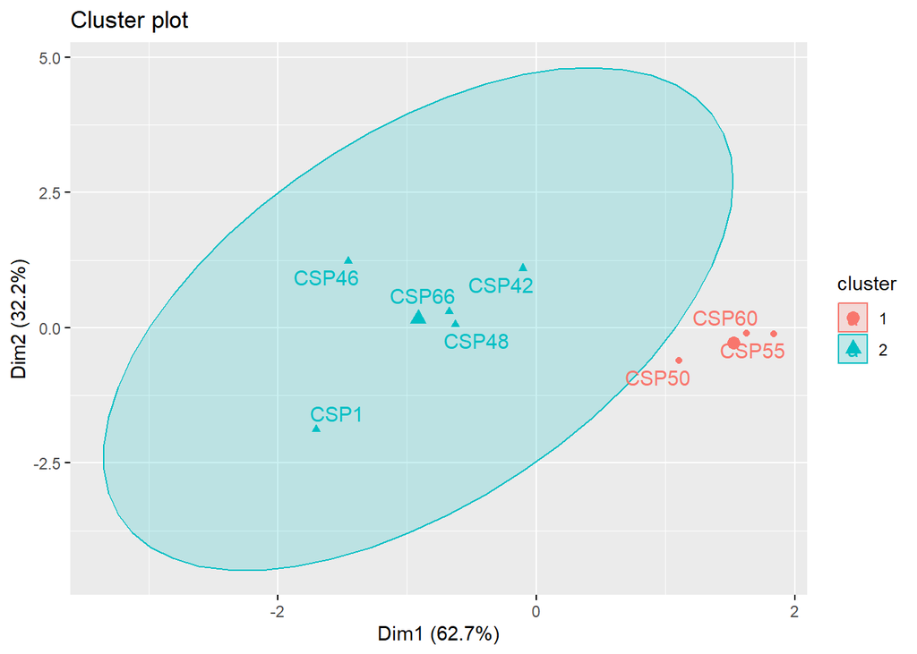

```r
fviz_cluster(km.res, data = df, centroids = 2, repel = TRUE, ellipse.type = "norm")
```

#### b) Clustering avec l’entierté des contrats

```r
data_2=read.csv("data_3.csv",header=TRUE,sep=";",fill=F)

#On crée une nouvelle colonnes pour pouvoir mettre en nom de colonnes les CSP bien qu'il y ait redondance (R veut que chaque nom de ligne soit différent)
data_2$col_1 <- paste(rownames(data_2), data_2$SocioCateg, sep = "_")
rownames(data_2)=data_2$col_1


#On élimine les colonnes SocioCateg et col_1 qui n'ont plus d'utilité
data_2=data_2[, -c(1,11)]

#On prend n lignes de notre data set de manière aléatoire car il n'est pas possible de travailler avec les 25000 lignes (manque de puissance)

n=2500
data_2_aleatoire=sample_n(data_2, n)
```

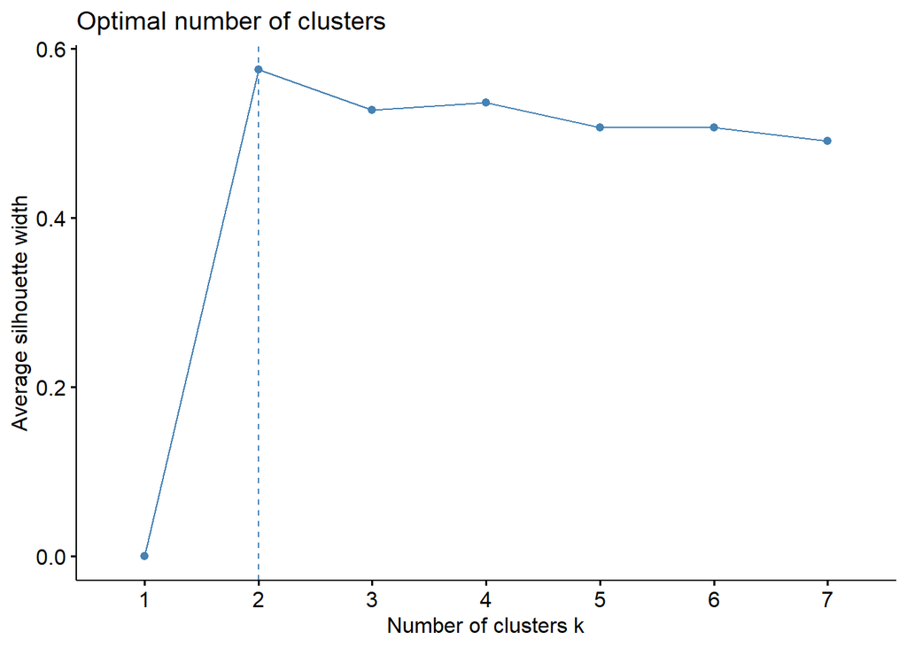

```r
#On centre chaque colonne de notre dataframe data afin de pouvoir procéder aux k-means

df_1=scale(data_2_aleatoire)
#Etude du nombre de clusterings que l'on va considérer grâce à différents critères

fviz_nbclust(data_2_aleatoire,  FUNcluster = kmeans ,c("silhouette", "wss", "gap_stat"),k.max=7)
```

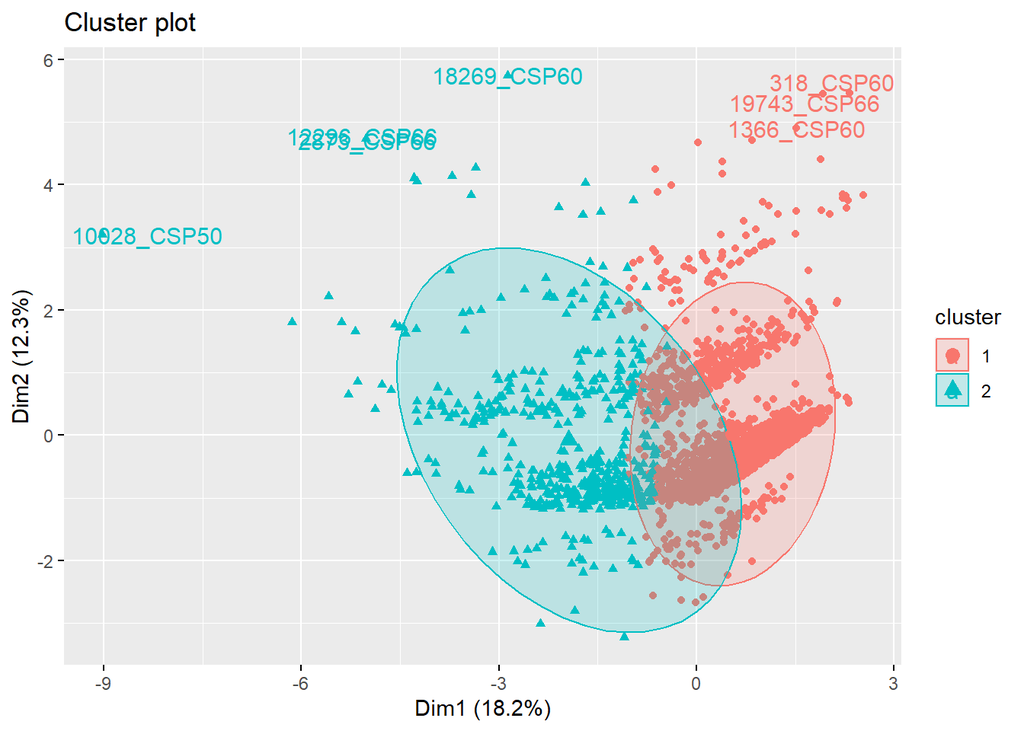

```r
km.res <- kmeans(df_1, 2, nstart = 10)

#On donne une couleur à chaque CSP pour mieux les visualiser au final
data_2_aleatoire$couleur <- ifelse(grepl("CSP50", row.names(data_2_aleatoire)), "red",ifelse(grepl("CSP42", row.names(data_2_aleatoire)),"blue",ifelse( grepl("CSP46", row.names(data_2_aleatoire)),"green",ifelse(grepl("CSP48", row.names(data_2_aleatoire)),"yellow",ifelse(grepl("CSP1", row.names(data_2_aleatoire)),"black",ifelse(grepl("CSP55", row.names(data_2_aleatoire)),"orange",ifelse(grepl("CSP60", row.names(data_2_aleatoire)),"pink","purple")))))))

fviz_cluster(km.res, data = df_1, centroids = 2, repel = TRUE, ellipse.type = "norm",#palette = data_2_aleatoire$couleur
             )
```

```r
x=km.res$cluster
df_x=data.frame(x)

#On crée une nouvelle colonne pour considérer que les CSP
df_x$CSP <- ifelse(grepl("CSP50", row.names(df_x)), "CSP50",ifelse(grepl("CSP42", row.names(df_x)),"CSP42",ifelse( grepl("CSP46", row.names(df_x)),"CSP46",ifelse(grepl("CSP48", row.names(df_x)),"CSP48",ifelse(grepl("CSP1", row.names(df_x)),"CSP1",ifelse(grepl("CSP55", row.names(df_x)),"CSP55",ifelse(grepl("CSP60", row.names(df_x)),"CSP60","CSP66")))))))

#On exporte ce data frame sous excel pour traiter ces données plus facilement
setwd("C:/Users/enceu/OneDrive/Bureau/Git_hub_Mémoire/Depot-memoire")
write.csv(df_x, file="df_x.csv", row.names = FALSE)
```

Après avoir retravailler les données sur Excel, cela ne semble pas concluant : on ne parvient à regrouper les CSP ensemble comme pour l’autre méthode.

### I) K-Means avec les variables explicatives quantitatives

On se focalise sur les variables quantitatives autres que ClaimInd et ClaimAmount dans cette section. On considérera toutes les autres variables quantitatives.

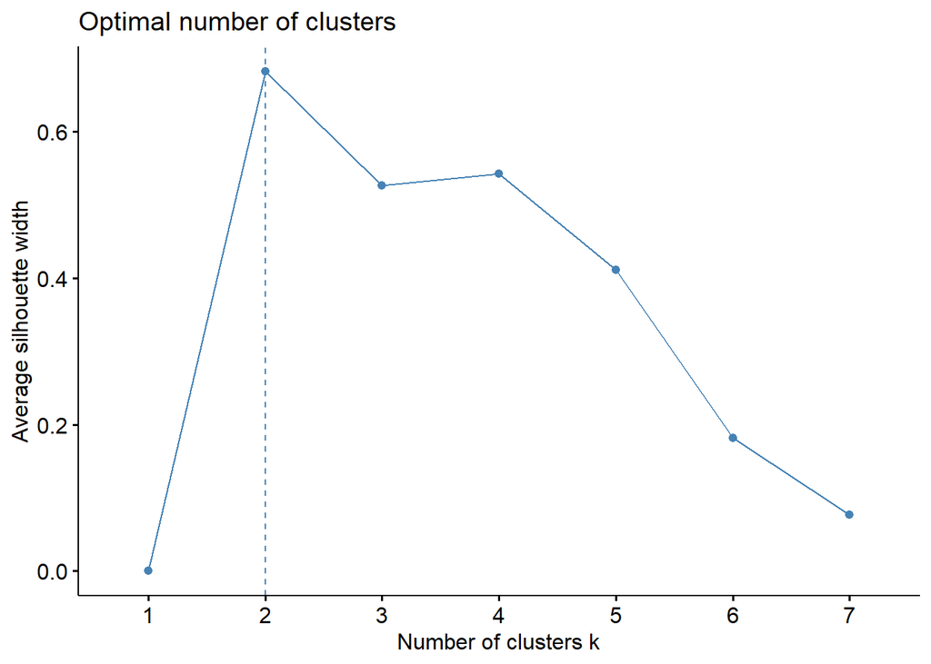

```r
data_CSP_3=read.csv("data_CSP_3.csv",header=TRUE,sep=";",fill=F,row.names=1)

#On centre chaque colonne de notre dataframe data afin de pouvoir procéder aux k-means
df_CSP_3=scale(data_CSP_3)
#Etude du nombre de clusterings que l'on va considérer grâce à différents critères

fviz_nbclust(data_CSP_3,  FUNcluster = kmeans ,c("silhouette", "wss", "gap_stat"),k.max=7)
```

```
## Too few points to calculate an ellipse
## Too few points to calculate an ellipse
## Too few points to calculate an ellipse
## Too few points to calculate an ellipse
```

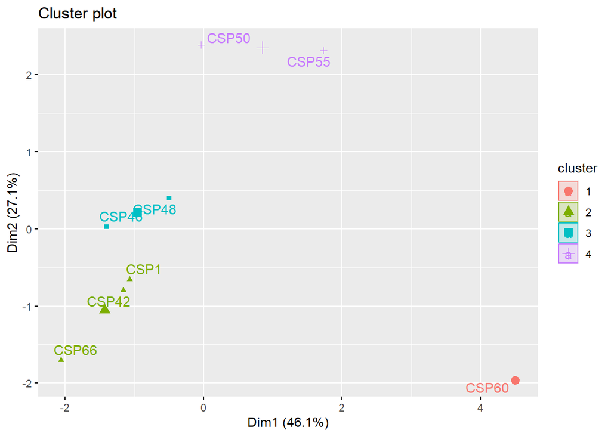

```r
km.res_CSP_3 <- kmeans(df_CSP_3, 4, nstart = 10)


fviz_cluster(km.res_CSP_3, data = df_CSP_3, centroids = 4, repel = TRUE, ellipse.type = "norm")
```

Ces résultats semblent cohérent et nous serviront dans la suite du code pour réduire le nombre de modalités de cette variable.

# Etude RiskArea

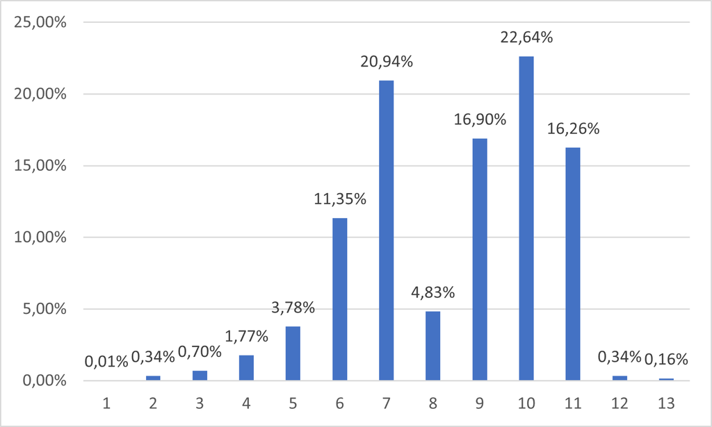

Cette première étude nous permet de regrouper les RiskArea avecs moins de 1,5% des assurés : RiskArea 1, 2, 3, 12 et 13. Il ne reste alors que les RiskArea 4,5,6,7,8,9,10 et 11 à étudier. Pour se faire, nous allons utiliser les k-means. s

### Clustering avec contrats regroupés par RiskArea

#### a) ClaimAmount moyen et le nombre de sinistres moyen par RiskArea

Dans cette section, on effectue un k-means sur les variables ClaimAmount moyen par RiskArea et idem pour le nombre de sinistres moyen

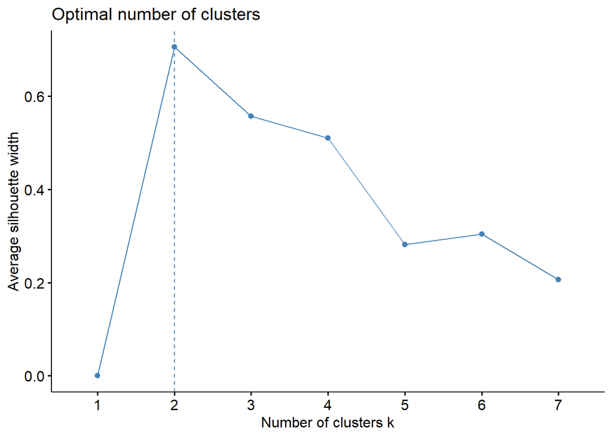

```r
data_R_1=read.csv("data_R_1.csv",header=TRUE,sep=";",fill=F,row.names=1)

#On centre chaque colonne de notre dataframe data afin de pouvoir procéder aux k-means
df_R_1=scale(data_R_1)
#Etude du nombre de clusterings que l'on va considérer grâce à différents critères

fviz_nbclust(data_R_1,  FUNcluster = kmeans ,c("silhouette", "wss", "gap_stat"),k.max=7)
```

```r
km.res_R_1 <- kmeans(df_R_1, 4, nstart = 10)
km.res_R_1
```

```
## K-means clustering with 4 clusters of sizes 1, 2, 2, 3
##
## Cluster means:
##   Moyenne.de.ClaimInd Moyenne.de.ClaimAmount
## 1           1.9097016             -0.1755615
## 2           0.5875762              1.4912943
## 3          -0.8794093             -0.1866566
## 4          -0.4420118             -0.8112380
##
## Clustering vector:
##  4  5  6  7  8  9 10 11
##  1  4  3  4  3  4  2  2
##
## Within cluster sum of squares by cluster:
## [1] 0.00000000 0.56932050 0.08788104 0.34975989
##  (between_SS / total_SS =  92.8 %)
##
## Available components:
##
## [1] "cluster"      "centers"      "totss"        "withinss"     "tot.withinss"
## [6] "betweenss"    "size"         "iter"         "ifault"
```

```
## Too few points to calculate an ellipse
## Too few points to calculate an ellipse
## Too few points to calculate an ellipse
## Too few points to calculate an ellipse
```

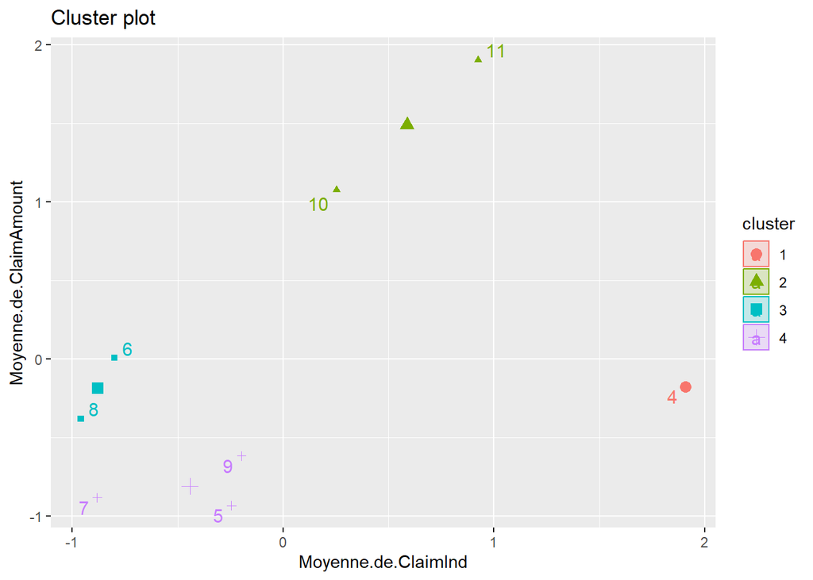

```r
fviz_cluster(km.res_R_1, data = df_R_1, centroids = 4, repel = TRUE, ellipse.type = "norm")
```

Cette modélisation ne semble pas concluante. Nous allons faire de même avec les variables explicatives quantitatives mises à notre disposition.

Ces résultats semblent cohérents.

#### c) Variables explicatives quantitatives (sans LicAge et ObtAge)

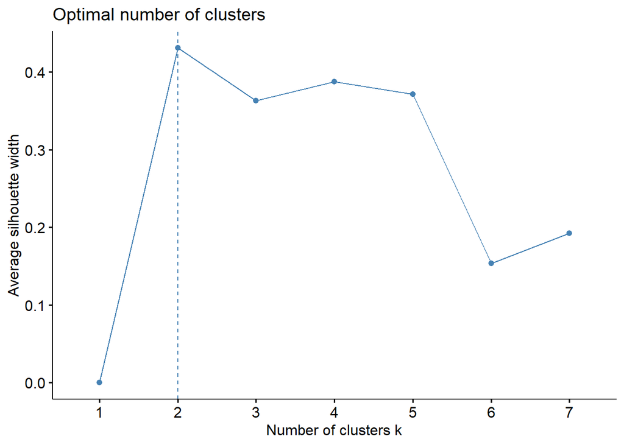

```r
data_R_3=read.csv("data_RiskArea_3.csv",header=TRUE,sep=";",fill=F,row.names=1)

#On centre chaque colonne de notre dataframe data afin de pouvoir procéder aux k-means
df_R_3=scale(data_R_3)
#Etude du nombre de clusterings que l'on va considérer grâce à différents critères

fviz_nbclust(data_R_3,  FUNcluster = kmeans ,c("silhouette", "wss", "gap_stat"),k.max=7)
```

```
## Too few points to calculate an ellipse
```

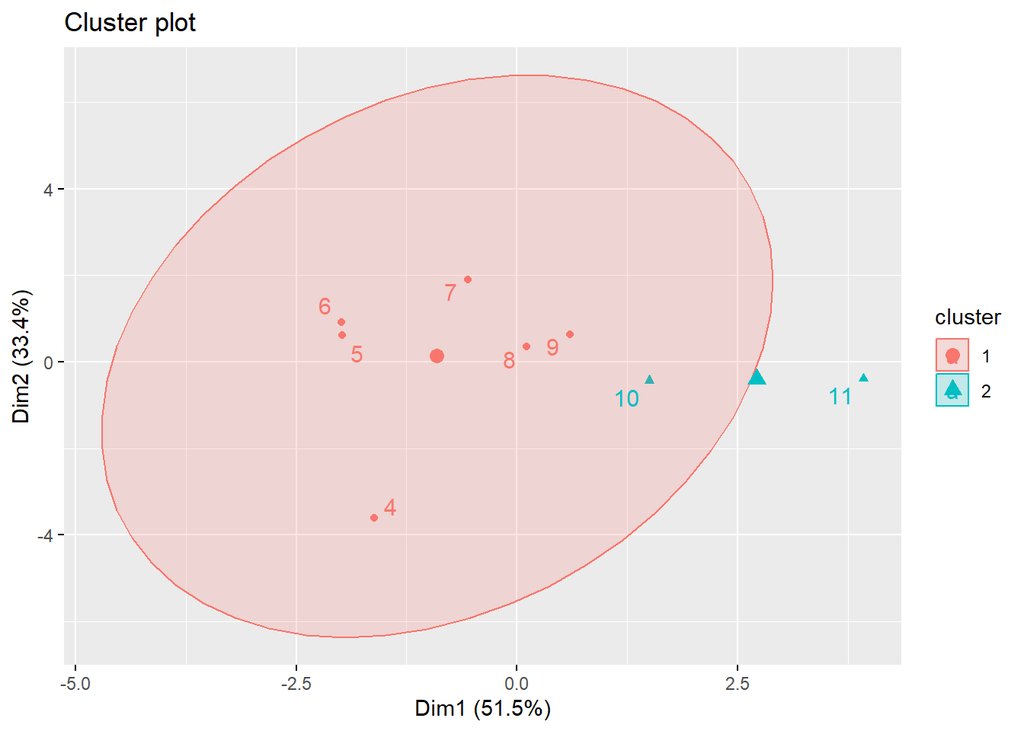

```r
km.res_R_3 <- kmeans(df_R_3, 2, nstart = 10)


fviz_cluster(km.res_R_3, data = df_R_3, centroids = 2, repel = TRUE, ellipse.type = "norm")
```

#### d) Variables explicatives quantitatives (tout)

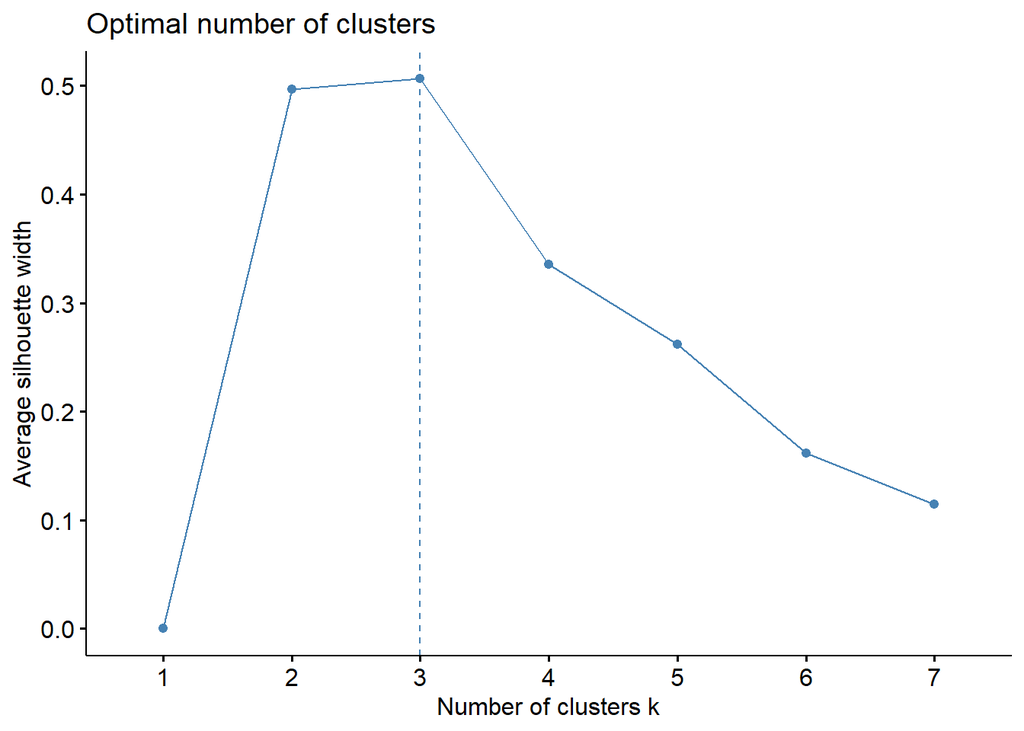

```r
data_R_4=read.csv("data_R_4.csv",header=TRUE,sep=";",fill=F,row.names=1)

#On centre chaque colonne de notre dataframe data afin de pouvoir procéder aux k-means
df_R_4=scale(data_R_4)
#Etude du nombre de clusterings que l'on va considérer grâce à différents critères

fviz_nbclust(data_R_4,  FUNcluster = kmeans ,c("silhouette", "wss", "gap_stat"),k.max=7)
```

```
## Too few points to calculate an ellipse
## Too few points to calculate an ellipse
```

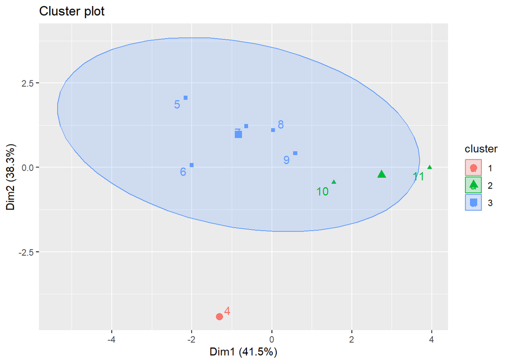

```r
km.res_R_4 <- kmeans(df_R_4, 3, nstart = 10)


fviz_cluster(km.res_R_4, data = df_R_4, centroids = 3, repel = TRUE, ellipse.type = "norm")
```

Nous considérerons ce clustering pour la suite de notre étude. Il semble très cohérent.